# Reaction Time - Pretest

Nicolas Restrepo

1/28/2020

## Analyzing Data from Pre-Test

```r
library(tidyverse)
library(kableExtra)
theme_set(theme_light())
```

I’m going to begin by loading in the data.

```r
# Load in the data
rt_pretest <- read_csv("data/rt_pretest.csv")
```

As a first step I am going to check how people did in the attention checks.

```r
# Delete unnecessary rows
rt_pretest <- rt_pretest[-(1:2),]

# How many people passed the attention checks?
rt_pretest %>%
  select(starts_with("att")) %>%
  mutate(passed = if_else(att_1 == "Harmless (K)" & att_2 == "Immoral (J)" & att_3 == "Harmful (J)", 1, 0)) %>%
  group_by(passed) %>%
  summarise(n())
```

```
## # A tibble: 1 x 2
##   passed `n()`
##    <dbl> <int>
## 1      1    20
```

Everyone passed!

Now let’s see whether we can get reaction time.

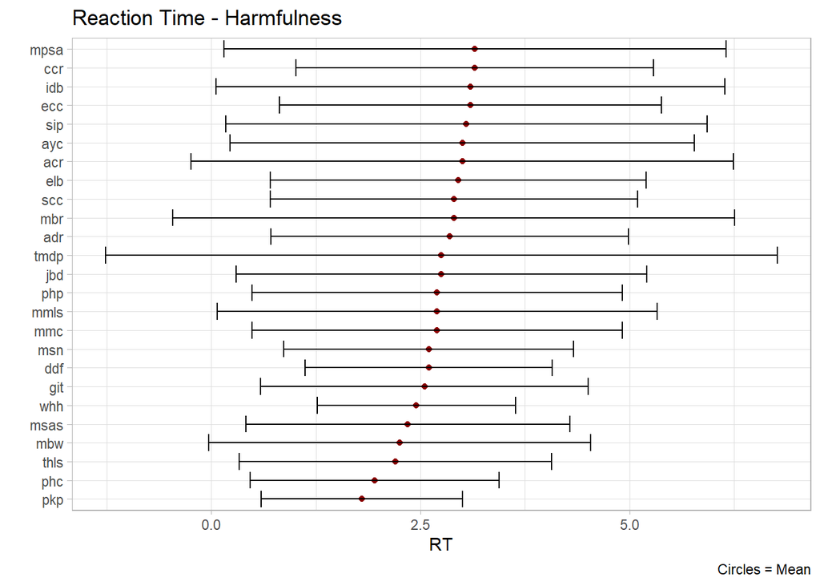

```r
# Put data in long format
rt_pretest_times <- rt_pretest %>%
  select(ends_with("Page Submit")) %>%
  mutate(ids = 1:20) %>%
  pivot_longer(1:50, names_to = "scenario", values_to = "reaction_time") %>%
  mutate(scenario = str_remove(scenario, "_t_Page Submit$"))

# Get summary statistics
gd <- rt_pretest_times %>%
  mutate(reaction_time = as.integer(reaction_time)) %>%
  group_by(scenario) %>%
  summarise(avg = mean(reaction_time),
            st_dv = sd(reaction_time)) %>%
  mutate(ci_lower = avg - 1.96*st_dv,
         ci_upper = avg + 1.96*st_dv)

# Now let's plot harm

# Keep only harm questions

gdh <- gd[str_which(gd$scenario, "h_"),]

# Plot harm questions

gdh %>%
  mutate(scenario = str_remove(scenario, "h_")) %>%
  ggplot(aes(x = reorder(scenario, avg), y = avg)) +
  geom_point(col = "darkred", fill = "darkred") +
  geom_errorbar(aes(ymin = ci_lower, ymax = ci_upper)) +
  coord_flip() +
  labs(x = "",
       y = "RT",
       title = "Reaction Time - Harmfulness",
       caption = "Circles = Mean")
```

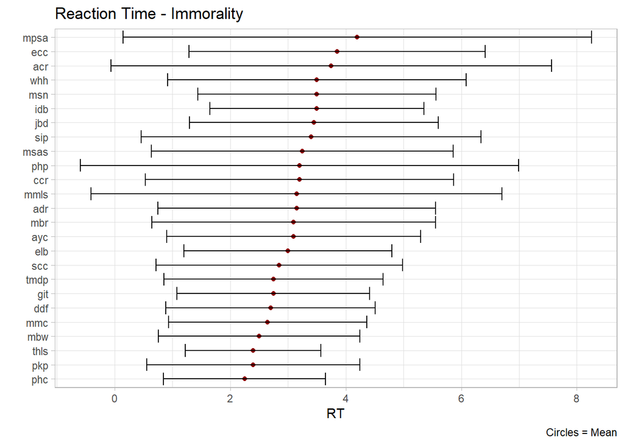

```r
# Get only Immorality questions
gdh <- gd[str_which(gd$scenario, "i_"),]

# Plot harm questions

gdh %>%
  mutate(scenario = str_remove(scenario, "i_")) %>%
  ggplot(aes(x = reorder(scenario, avg), y = avg)) +
  geom_point(col = "darkred", fill = "darkred") +
  geom_errorbar(aes(ymin = ci_lower, ymax = ci_upper)) +
  coord_flip() +
  labs(x = "",
       y = "RT",
       title = "Reaction Time - Immorality",
       caption = "Circles = Mean")
```

```r
rt_pretest_times %>%
  mutate(reaction_time = as.integer(reaction_time)) %>%
  summarise(avg = mean(reaction_time),
            stv = sd(reaction_time)) %>%
  mutate(ci_lower = avg - 1.96*stv,
         ci_upper = avg + 1.96*stv) %>%
  kable(.) %>%
  kable_styling()
```

| avg | stv | ci_lower | ci_upper |
| --- | --- | --- | --- |
| 2.901 | 1.30265 | 0.3478068 | 5.454193 |

```r
sum(rt_pretest_times$reaction_time < 1)
```

```
## [1] 1
```

```r
sum(rt_pretest_times$reaction_time > 5.46)
```

```
## [1] 69
```

```r
sum(rt_pretest_times$reaction_time > 9)
```

```
## [1] 5
```

It is also encouraging that only one of the responses (total = 1000) was below 1 second. This means that no one just clicked their way through the survey. Also, the upper bound of the 95% confidence interval of reaction times is 5.46. 6.9% of the responses were longer than this threshold. This indicates that most people took a “reasonable” time to answer questions. Now, we will have to think more about outliers later but it is encouraging that - in general - respondents were neither just clicking through the questions nor taking too long.